# A5_singhvis

Vishal Singh

October 29, 2019

```r
nhanes_raw = NHANESraw
nhanes_raw = nhanes_raw %>% dplyr::select(Diabetes, Age, WTINT2YR) %>% drop_na(Diabetes) %>%
    mutate(Diabetes = ifelse(Diabetes == "No", 0, 1))

nhanes = NHANES %>% dplyr::select(Diabetes, Age) %>% drop_na(Diabetes) %>% mutate(Diabetes = ifelse(Diabetes ==
    "No", 0, 1))
```

## 1

### a.

```r
prop_diabetes_nhanes = nhanes %>% group_by(Diabetes) %>% summarise(percent = n()) %>%
    mutate(percent = percent/sum(percent))

prop_diabetes1a = prop_diabetes_nhanes$percent[prop_diabetes_nhanes$Diabetes ==
    1]
print(paste0("Proportion of all U.S. residents with diabetes: ", round(prop_diabetes1a,
    5)))
```

```
## [1] "Proportion of all U.S. residents with diabetes: 0.07709"
```

### b.

```r
prop_diabetes_nhanesraw = nhanes_raw %>% group_by(Diabetes) %>% summarise(percent = n()) %>%
    mutate(percent = percent/sum(percent))

prop_diabetes1b = prop_diabetes_nhanesraw$percent[prop_diabetes_nhanesraw$Diabetes ==
    1]
print(paste0("Proportion of people in the sample with diabetes: ", round(prop_diabetes1b,
    5)))
```

```
## [1] "Proportion of people in the sample with diabetes: 0.08767"
```

### c.

```r
prop_diabetes_nhanesraw_wt = nhanes_raw %>% group_by(Diabetes) %>% summarise(percent = sum(WTINT2YR)) %>%
    mutate(percent = percent/sum(percent))

prop_diabetes1c = prop_diabetes_nhanesraw_wt$percent[prop_diabetes_nhanesraw_wt$Diabetes ==
    1]
print(paste0("Proportion of all U.S. residents with diabetes (weighted): ",
    round(prop_diabetes1c, 5)))
```

```
## [1] "Proportion of all U.S. residents with diabetes (weighted): 0.07984"
```

The proportion estimated from the data NHANES and NHANESraw (unweighted) is comparable (~8%) and also the proportion estimated from NHANESraw using unweighted and weighted data is also comaparable.

## 2

### a.

Visualize the model:

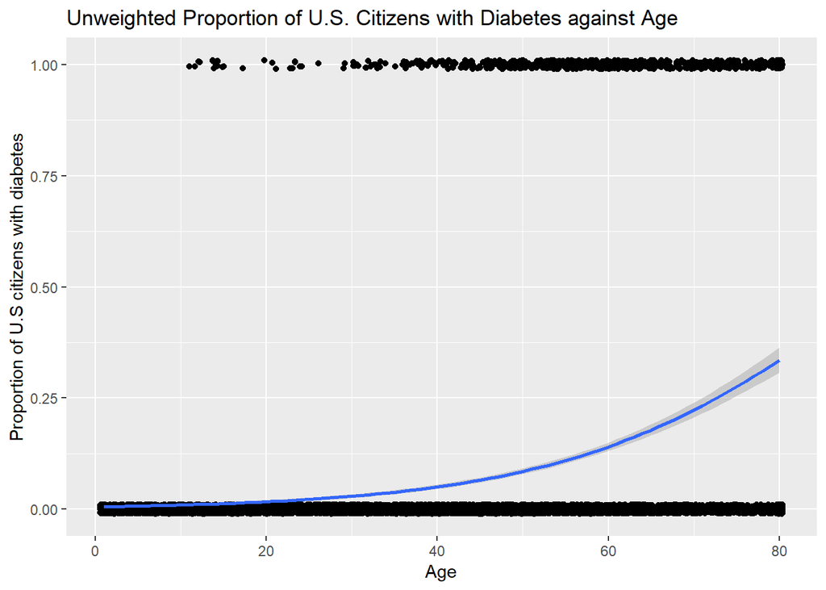

```r
ggplot(nhanes, aes(Age, Diabetes)) + geom_jitter(height = 0.01) + geom_smooth(method = "glm",
    method.args = list(family = "binomial")) + labs(title = "Unweighted Proportion of U.S. Citizens with Diabetes against Age",
    x = "Age", y = "Proportion of U.S citizens with diabetes")
```

Fit a logistic regression:

```r
diabetes.logit = glm(Diabetes ~ Age, family = binomial, data = nhanes)
summary(diabetes.logit)
```

```
##
## Call:
## glm(formula = Diabetes ~ Age, family = binomial, data = nhanes)
##
## Deviance Residuals:
##     Min       1Q   Median       3Q      Max
## -0.9037  -0.4218  -0.2506  -0.1517   3.0274
##
## Coefficients:
##             Estimate Std. Error z value Pr(>|z|)
## (Intercept) -5.19218    0.13240  -39.22   <2e-16 ***
## Age          0.05634    0.00221   25.49   <2e-16 ***
## ---
## Signif. codes:  0 '***' 0.001 '**' 0.01 '*' 0.05 '.' 0.1 ' ' 1
##
## (Dispersion parameter for binomial family taken to be 1)
##
##     Null deviance: 5355.2  on 9857  degrees of freedom
## Residual deviance: 4495.1  on 9856  degrees of freedom
## AIC: 4499.1
##
## Number of Fisher Scoring iterations: 6
```

**Interpretation**  
The coefficient of regression is 0.05634, therefore, we can say that with a unit increase in the value of Age will result in a increase of 0.05634 in the value of log of odds ratio.

### b.

Fit a logistic regression:

```r
survey.weights = (nhanes_raw$WTINT2YR/1)
diabetes.logit.wt = glm(Diabetes ~ Age, family = binomial, data = nhanes_raw,
    weights = survey.weights)
summary(diabetes.logit.wt)
```

```
##
## Call:
## glm(formula = Diabetes ~ Age, family = binomial, data = nhanes_raw,
##     weights = survey.weights)
##
## Deviance Residuals:
##    Min      1Q  Median      3Q     Max
##      0       0       0       0    3768
##
## Coefficients:
##               Estimate Std. Error    z value Pr(>|z|)
## (Intercept) -4.979e+15  5.396e+03 -9.227e+11   <2e-16 ***
## Age          3.192e+13  1.242e+02  2.570e+11   <2e-16 ***
## ---
## Signif. codes:  0 '***' 0.001 '**' 0.01 '*' 0.05 '.' 0.1 ' ' 1
##
## (Dispersion parameter for binomial family taken to be 1)
##
##     Null deviance:  334158316  on 19459  degrees of freedom
## Residual deviance: 3454325322  on 19458  degrees of freedom
## AIC: 3454324481
##
## Number of Fisher Scoring iterations: 4
```

```r
# Describing the fit
our.logit = function(x) {
    coe = coef(diabetes.logit.wt)
    y = coe[1] + coe[2] * x
    return(exp(y)/(1 + exp(y)))
}
```

Visualize the model:

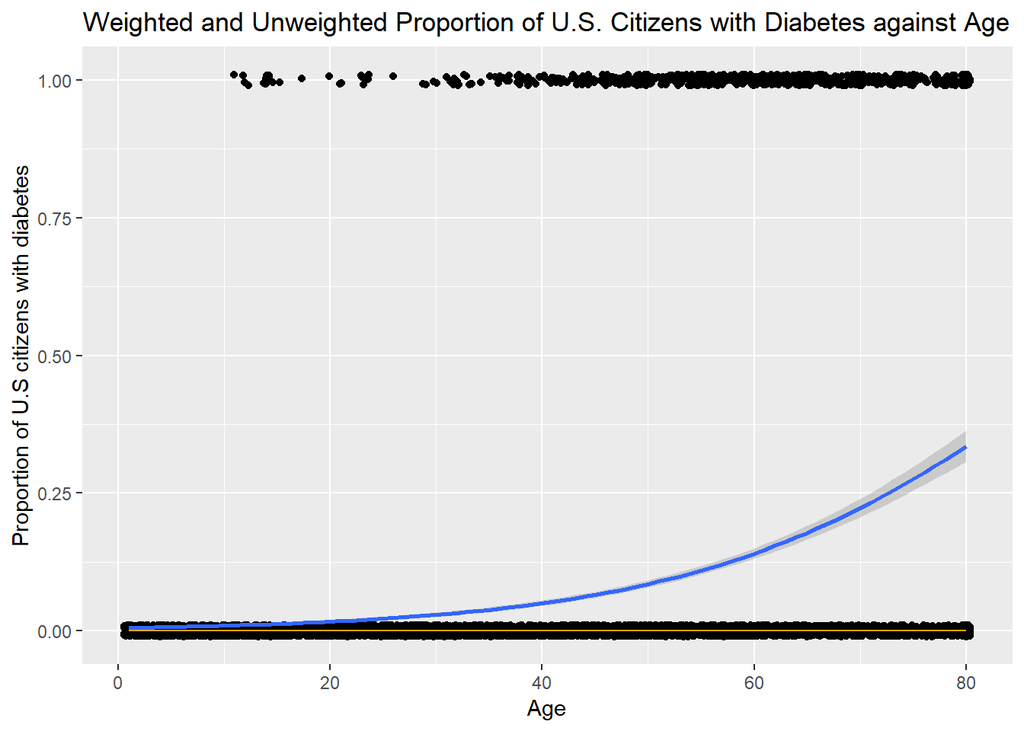

```r
ggplot(nhanes, aes(Age, Diabetes)) + geom_jitter(height = 0.01) + geom_smooth(method = "glm",
    method.args = list(family = "binomial")) + stat_function(fun = our.logit,
    color = "orange") + labs(title = "Weighted and Unweighted Proportion of U.S. Citizens with Diabetes against Age",
    x = "Age", y = "Proportion of U.S citizens with diabetes")
```

**Interpretation**  
The coefficient of regression is 3.192e+13, therefore, we can say that with a unit increase in the value of Age will result in a increase of 3.192e+13 in the value of log of odds ratio.  
The coefficients of the two models are very different and the scale of coefficients are not comparable.

## 3

```r
nhanes_raw_grp_age_diabetes = nhanes_raw %>% group_by(Age, Diabetes) %>% summarise(wt_sum = sum(WTINT2YR))

nhanes_raw_grp_age = nhanes_raw %>% group_by(Age) %>% summarise(wt_sum = sum(WTINT2YR))

nhanes_prop = nhanes_raw_grp_age_diabetes %>% left_join(nhanes_raw_grp_age,
    by = "Age") %>% mutate(age_diabetes_prop = wt_sum.x/wt_sum.y) %>% filter(Diabetes ==
    1)
```

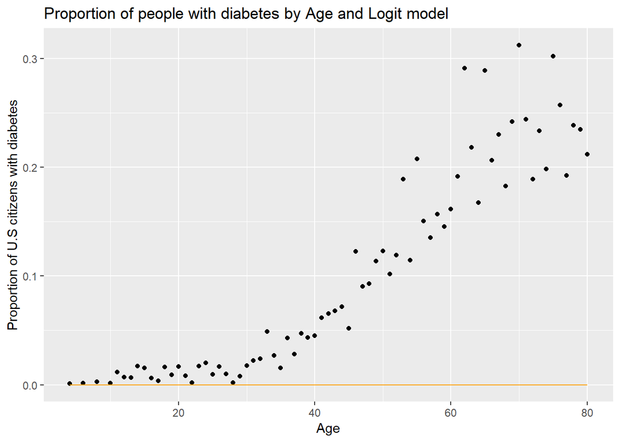

```r
ggplot(nhanes_prop, aes(Age, age_diabetes_prop)) + geom_point() + stat_function(fun = our.logit,
    color = "orange") + labs(title = "Proportion of people with diabetes by Age and Logit model",
    x = "Age", y = "Proportion of U.S citizens with diabetes")
```

The curve for the proportions for people who have diabetes does not match with the curve for logits using weights.  
The weights for people which do not have diabetes is very high compared to people who have diabetes, therefore, our model only predicts 0.